# wuebker_assignment3

## MFE Spring 2021

## Assignment 3

Student Name: Rick Wuebker

ID: richard_wuebker

Solved in team: No

# 1. Integration

> **(a) Prove that the sequence $f_1, f_2, ...$ converges uniformly to a continuous function. $f: [0,1]\rightarrow \mathbb{R}$ by showing that it is a Cauchy Sequence in the sup-norm.**

```python
import numpy as np
import matplotlib.pyplot as plt
import matplotlib.style as style
style.use('ggplot')
```

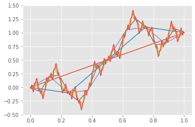

```python
def build_process(n=4):
    fs = {}
    fs[1] = {0:0, 0.5: 0.5, 1.0:1.0}
    plt.plot(list(fs[1].keys()), list(fs[1].values()))

    for j in range(2, n + 1):
        k = 0
        J = j - 1
        domain_len = 2**j + 1
        domain = np.linspace(0, 1, domain_len)
        f = {}
        for ix, t in enumerate(domain):
            if t in fs[j-1]:
                f[t] = fs[j-1][t]
            else:
                k += 1
                prev = (fs[j-1][domain[ix-1]] + fs[j-1][domain[ix+1]])/2
                new_val = prev + (-1)**(k + J + 1) * 2**((-J/2) - 1)
                f[t] = new_val

        fs[j] = f
        plt.plot(list(fs[j].keys()), list(fs[j].values()))
    return fs

fs = build_process(8)
```

$$ f_{J+1}(t) - f_J(t) \in \{0, -2^{-(j/2 + 1)}, 2^{-(j/2 + 1)} \} $$

$$ sup\|f_{J+1}(t) - f_J(t)\| = \frac{1}{2^{(J/2 + 1)}} $$

The sup norm will tend to zero as J gets larger, thus it is a cauchy sequence under this norm and the functions converge uniformly.

> **(b) Consider an arbitrary dyadic point, $t = k2^{-J}$ for some $J > 0$ and $0\leq k \leq 2^J$. Show that for any such point,**

$$ |f_{J'}(t + 2^{-J'}) - f_{J'}(t)| \geq \frac{2^{-J/2}}{8} $$

Let $t$, $t + 2^{-(J+1)}$, $ \in X^{J+1}$

$$\implies f_{J}(t) = f_{J+1}(t) \tag{1}$$

$$\implies f_{J}(t + 2^{-J}) = f_{J+1}(t + 2^{-J}) \tag{1}$$

$ f_{J+1}(t + 2^{-(J+1)}) = \frac{f_J(t) + f_J(t+2^{-J})}{2} + 2^{-J/2 - 1} \;\;\;\;\;$ or $\;\;\;\; f_{J+1}(t + 2^{-(J+1)}) = \frac{f_J(t) + f_J(t+2^{-J})}{2} - 2^{-J/2 - 1}$

Depending on J, k. Starting with $+2^{-J/2-1}$:

$$f_{J+1}(t+2^{-(J+1)}) = \frac{1}{2}\bigg(f_J(t + 2^{-J}) - f_J(t)\bigg) + 2^{-J/2 - 1}$$

$$f_{J+1}(t+2^{-(J+1)}) = \frac{1}{2}\bigg(f_{J+1}(t + 2^{-J}) - f_{J+1}(t)\bigg) + 2^{-J/2 - 1}$$

$$f_{J+1}(t+2^{-(J+1)}) = \frac{1}{2}\bigg(f_{J+1}(t + 2^{-J}) - f_{J+1}(t + 2^{-(J+1)}) + f_{J+1}(t + 2^{-(J+1)})- f_{J+1}(t)\bigg) + 2^{-J/2 - 1}$$

$$f_{J+1}(t+2^{-(J+1)}) = \frac{1}{2}\bigg(f_{J+1}(t + 2^{-J}) - f_{J+1}(t + 2^{-(J+1)})\bigg) + \frac{1}{2}\bigg(f_{J+1}(t + 2^{-(J+1)})- f_{J+1}(t)\bigg) + 2^{-J/2 - 1}$$

$$\frac{1}{2}\bigg(f_{J+1}(t + 2^{-(J+1)})- f_{J+1}(t)\bigg) = f_{J+1}(t+2^{-(J+1)}) - \frac{1}{2}\bigg(f_{J+1}(t + 2^{-J}) - f_{J+1}(t + 2^{-(J+1)})\bigg) - 2^{-J/2 - 1}$$

$$\bigg(f_{J+1}(t + 2^{-(J+1)})- f_{J+1}(t)\bigg) = 2f_{J+1}(t+2^{-(J+1)}) - \bigg(f_{J+1}(t + 2^{-J}) - f_{J+1}(t + 2^{-(J+1)})\bigg) - 2^{-J/2}$$

Unfortunately I'm not seeing a path to the given result.

> **(c) Use your result in (b) to show that $f \notin C^{\alpha}([0,1], \mathbb{R})$ for any dyadic t, for any $\alpha > \frac{1}{2}$**

Unfortunately I"m not seeing this solution either.

> **(d) Show that $f_J(t) = 1 - f_J(1-t)$ for all J and t, and use this result to show that $\int_0^1 f_J(t)dt = \frac{1}{2}$ for all $J \geq 1$.**

This sequence of functions, by construction all begin at 0 and end at 1 in the range and over the domain [0,1] and are reflectively symmetric about the line $f(t) = t$ and the point $t = \frac{1}{2}$.

As a consequence of this, $f_J(t) = 1 - f_J(1 -t)$ for all J and t. And:

$$\int_0^{\frac{1}{2}} [f_J(t) - t]dt = -\int_{\frac{1}{2}}^1[f_J(t) - t]dt$$

$$\int_0^{\frac{1}{2}} [f_J(t) - t]dt + \int_{\frac{1}{2}}^1[f_J(t) - t]dt = 0$$

$$\int_0^{\frac{1}{2}}f_J(t)dt - \int_0^{\frac{1}{2}}tdt + \int_{\frac{1}{2}}^1f_J(t)dt - \int_{\frac{1}{2}}^1tdt = 0$$

$$\int_0^{\frac{1}{2}}f_J(t)dt + \int_{\frac{1}{2}}^1f_J(t)dt = \int_0^{\frac{1}{2}}tdt + \int_{\frac{1}{2}}^1tdt$$

$$\int_0^1f_J(t)dt = \int_0^1tdt = \frac{1}{2}$$

> **(e) Use your result in (d) to show that $\int_0^1f(t)dt = \frac{1}{2}$**

This series of functions converge uniformly so the integral equates to $\frac{1}{2}$ no matter the J, so even as $J \rightarrow \infty$ the integral will equal to $\frac{1}{2}$.

> **(f) For $t = k2^{-J}$, $0 \leq k < 2^J$, assume $f_J(t) = a$ and $f_J(t+2^{-J}) = b$. It follows that $\big(f_J(t+2^{-J}) - f_J(t)\big)^2 = (b - a)^2$. Show that:**

$$\big(f_{J+1}(t + 2^{-J-1}) - f_{J+1}(t)\big)^2 + \big(f_{J+1}(t+2^{-J}) - f_{J+1}(t + 2^{-J-1})\big)^2 = \frac{(b-a)^2}{2} + 2^{-J-1} $$

$$(f_{J+1}(t + 2^{-J-1}) - a)^2 + (b - f_{J+1}(t + 2^{-J-1}))^2$$

Note: $f_{J+1}(t + 2^{-J-1}) = \frac{a+b}{2} \pm 2^{-J/2-1}$

$$(\frac{a+b}{2} \pm 2^{-J/2-1} - a)^2 + (b - \frac{a+b}{2} \pm 2^{-J/2-1})^2$$

> **(g) Use the result in (f) to show that $V_{J+1} = \frac{V_t}{2} + \frac{1}{2}$ for all $J\geq 1$, and that it therefore follow that:**

$$V_J = 1 - 2^{-J}$$

# 2. ODEs

> **(a) What is the value at $t=0$ of a contract that makes a payment at time $t=10$ of USD 1000?**

Given the continuously compounded short interest rate $ r(t) = \frac{1}{20 + \frac{t}{2}}$

$$ \frac{dB}{B} = r(t)dt$$

$$ \int_0^t\frac{1}{B}dB = \int_0^t r(t)dt $$

$$ \int_0^t\frac{1}{B}dB = \ln B\biggr|_0^t =\ln\bigg(\frac{B_t}{B_0}\bigg) = \int_0^t r(s)ds = 2\ln(20 + \frac{s}{2})\biggr|_0^t = 2\ln(20+\frac{t}{2}) - 2\ln(20)$$

$$ \implies B(0) = B(t)e^{-(2\ln(20 + \frac{t}{2}) - 2\ln(20))} $$

$$B(0) = B(10)e^{-(2\ln(20 + \frac{10}{2}) - 2\ln(20))}$$

$$ B(0) = 1000e^{-0.446287} \approx 640.00 $$

> **(b) Derive an expression for the value of the asset as a function of time, $V(t), t \geq 0$**

$$ \frac{dV}{dt} = r(t)V(t) + I(t) $$

Where $I(t) = 300$ until $V(t)$ reaches $V = 3312$, at which point $I(t)$ instantaneously switches to $I(t) = 0$

$$V' - r(t)V(t) = I(t) $$

$$P(t) = -\int_0^t \frac{1}{20+\frac{s}{2}}ds = -2\ln(20 + \frac{s}{2})\biggr|_0^t = -2(\ln(20+\frac{t}{2}) - \ln(20))$$

$$\int_0^t e^{P(t)} I(t) dt = 300\int_0^t e^{-2(ln(20+\frac{t}{2}) - \ln(20))}dt = 300\int_0^t \frac{e^{\ln\big[20^2\big]}}{e^{\ln\big[(20+ \frac{t}{2})^2\big]}}dt = 300\int_0^t \frac{20^2}{(20+ \frac{t}{2})^2}dt$$

$$ = (300)(400)\int_0^t (20 + \frac{t}{2})^{-2}dt = (300)(400)(-2)(20 + \frac{t}{2})^{-1}\biggr|_0^t = -240000\bigg[(20 + \frac{t}{2})^{-1} - \frac{1}{20}\bigg]$$

$$V(t) = \frac{e^{\ln\big[(20 + \frac{t}{2})^2\big]}}{e^{\ln(400)}} \big[-240000\bigg((20+\frac{t}{2})^{-1} - \frac{1}{20} \bigg) + b\big]$$

$$V(t) = \frac{(20 + \frac{t}{2})^2}{400} \big[-240000\bigg((20+\frac{t}{2})^{-1} - \frac{1}{20} \bigg) + b\big]$$

$$V(0) = \big[-240000\bigg((\frac{1}{20} - \frac{1}{20} \bigg) + b\big] = b = 300$$

Now need to determine when $V = 3312$

$$ 3312 = \frac{(20 + \frac{t}{2})^2}{400} \big[-240000\bigg((20+\frac{t}{2})^{-1} - \frac{1}{20} \bigg) + 300\big]$$

$$1324800 = \bigg[-240000\bigg((20 + \frac{t}{2} - \frac{(20+\frac{t}{2})^2}{20}\bigg) + 300(20 + \frac{t}{2})^2 \bigg] $$

$$1324800 = \bigg[-240000\bigg((20 + \frac{t}{2} - \frac{400 + 20t + \frac{t^2}{4}}{20}\bigg) + 300(400 + 20t +\frac{t^2}{4}) \bigg] $$

$$1324800 = \bigg[-240000\bigg((20 + \frac{t}{2} - 20 - t - \frac{t^2}{80}\bigg) + 300(400 + 20t +\frac{t^2}{4}) \bigg] $$

$$1324800 = \bigg[-240000\bigg((\frac{t}{2} - t - \frac{t^2}{80}\bigg) + 120000 + 6000t + 75t^2 \bigg] $$

$$1324800 = \bigg[120000t +3000t^2 + 120000 + 6000t + 75t^2 \bigg] $$

$$1324800 = \bigg[3075t^2 + 126000t + 120000\bigg] $$

$$\bigg[3075t^2 + 126000t - 1204800\bigg] = 0 $$

Using a quadratic formula calculator $t \in \{8, -48.9756 \}$

At $t = 8$ the fund has reached 3312 so the continuous contributions will stop then.

$$V(t) = \left\{ \begin{array}{ll} \frac{(20 + \frac{t}{2})^2}{400} \big[-240000\bigg((20+\frac{t}{2})^{-1} - \frac{1}{20} \bigg) + 300\big] \quad 0 \leq t \leq 8 \\ 3312e^{(2\ln(20 + \frac{t-8}{2}) - 2\ln(20))} \quad t > 8 \end{array} \right. $$